# Function documentations & Examples

Zach Wang

8/19/2020

## 1. Function Implementations

### 1.1 function 1: *ReadFile* and attach packages

### 1.2. function 2: *Wave*

### 1.3. function 3: *fourier_smooth*

### 1.4. function 4: *fPCA.nodes*

### 1.5. function 5: *node.scaler*

### 1.6. function 6: *row.check*

# **main script**

## 2. Examples of using each function

### 2.1 Read data

```r
file_loc = '/Users/hanwang/desktop/Git_desktop/Functional_Data_Analysis/data_15may2020.csv'
data_15may2020 <- ReadFile(file_loc, time_subset=c(1:600), node_subset=c(1:32))
```

read in data from the specified file location

### 2.2 *Wave* function

**Wave** function takes the a single node data as input, and transforms the data to N complete sinusoidal cycles. Below are some examples of using Wave function on data of a single node.

- **Notes:**
  - *Wave* has two arguements:
    - node_data: input takes one column at a time (here is a 600x1 matrix)
    - register: set to 0 if want the result to be the original curves; set to 1 if want the result curves to center around 0

The following 2 plots are generated by the *Wave* function applied on the raw data of node 1 (before smoothing).

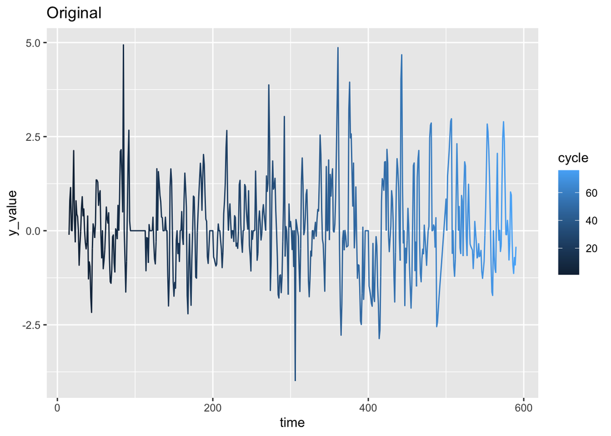

```r
# extract periodic curves from a single node (before smoothing)
node1 = Wave(data_15may2020[,1], register=0)
ggplot(node1, aes(time, y_value,group=cycle, colour=cycle)) + geom_line() + theme(legend.position="right")+ ggtitle("Original")
```

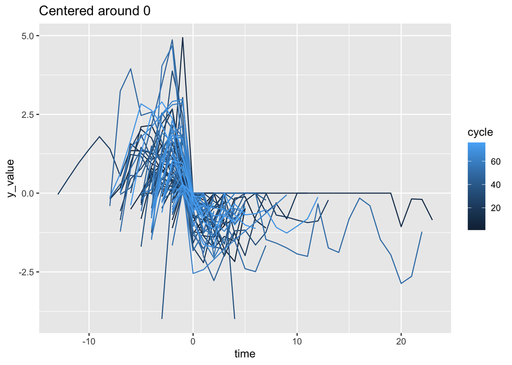

```r
node1 = Wave(data_15may2020[,1], register=1)
ggplot(node1, aes(time, y_value,group=cycle, colour=cycle)) + geom_line() + theme(legend.position="right") + ggtitle("Centered around 0")
```

### 2.3 *fourier_smooth* functions

The following 2 plots are generated by *Wave* functions on the transformed data of node 1 (after smoothing). In the examples below, another function, **fourier_smooth** is called first to smooth the raw data using fourier basis functions.

- **Notes:**
  - *fourier_smooth* has four arguments:
    - data_mat: Input data matrix, which should contains the entire data set, but we can use other arguments to select only *“subsets”* or *“Region of interest”* of the data for analysis
    - time_subset: specify a subset of time or all for analysis
    - node_subset: specify a subset of node or all for analysis
    - k: specify the *“nummber of fourier basis functions”* to be used in the smoothing process

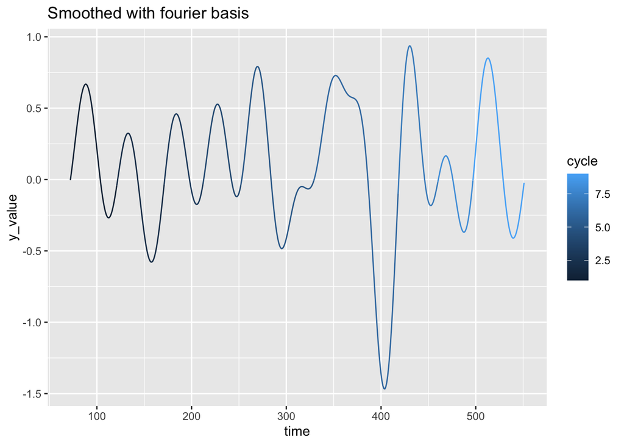

```r
# extract periodic curves from a single node (after smoothing)
result_obj <- fourier_smooth(data_mat=data_15may2020, time_subset=c(1:600), node_subset=c(1), k=32)
node1_smoothed = eval.fd(c(1:600),result_obj$fd)
node1_smoothed_extraced = Wave(node1_smoothed, register=0)
ggplot(node1_smoothed_extraced, aes(time, y_value,group=cycle, colour=cycle)) + geom_line() + theme(legend.position="right")+ ggtitle("Smoothed with fourier basis")
```

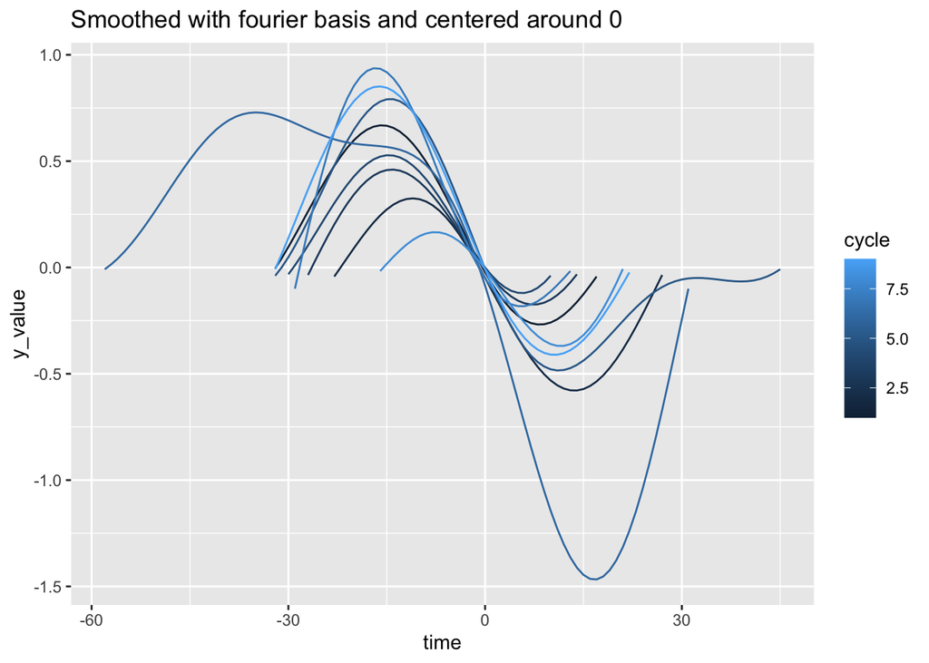

```r
node1_smoothed_extraced = Wave(node1_smoothed, register=1)
ggplot(node1_smoothed_extraced, aes(time, y_value,group=cycle, colour=cycle)) + geom_line() + theme(legend.position="right")+ ggtitle("Smoothed with fourier basis and centered around 0")
```

### 2.4 *fPCA.nodes* function

**fPCA.nodes** function takes input data in matrix form (N rows x M columns), and transform the data to N complete sinusoidal cycles – there has to be more than one column, otherwise PCA won’t make sense.

- **Notes:**
  - *fPCA.nodes* has four arguements:
    - data_mat: data in matrix form (N rows x M columns).
    - k: number of fourier basis functions used
    - nharm: number of Principle Components interested
    - plt: set to 1 if want to generate plot; set to 0 if don’t want plot

Below are some examples of using **fPCA.nodes** function on the original data.

```r
# fPCA on raw data
rotpcalist = fPCA.nodes(data_15may2020, k=11, nharm=2, plt=1)
```

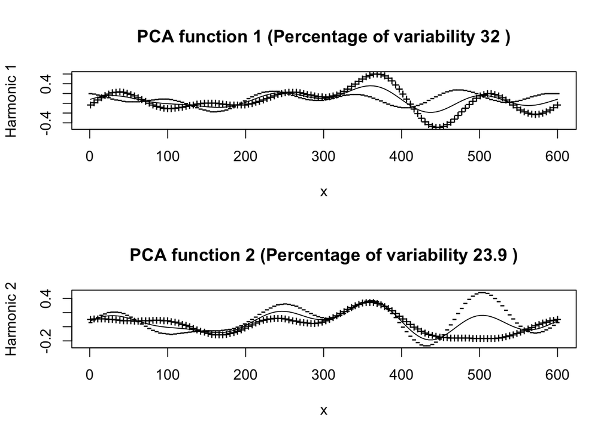